*You are currently looking at **version 1.3** of this notebook. To download notebooks and datafiles, as well as get help on Jupyter notebooks in the Coursera platform, visit the [Jupyter Notebook FAQ](https://www.coursera.org/learn/python-machine-learning/resources/bANLa) course resource.*

# Assignment 1 - Introduction to Machine Learning

For this assignment, you will be using the Breast Cancer Wisconsin (Diagnostic) Database to create a classifier that can help diagnose patients. First, read through the description of the dataset (below).

```python
import numpy as np
import pandas as pd
from sklearn.datasets import load_breast_cancer

cancer = load_breast_cancer()

#print(cancer.DESCR) # Print the data set description
```

The object returned by `load_breast_cancer()` is a scikit-learn Bunch object, which is similar to a dictionary.

```python
cancer.keys()
```

```
dict_keys(['data', 'target', 'target_names', 'DESCR', 'feature_names'])
```

### Question 0 (Example)

How many features does the breast cancer dataset have?

*This function should return an integer.*

```python
# You should write your whole answer within the function provided. The autograder will call
# this function and compare the return value against the correct solution value
def answer_zero():
    # This function returns the number of features of the breast cancer dataset, which is an integer.
    # The assignment question description will tell you the general format the autograder is expecting

    return len(cancer['feature_names'])

# You can examine what your function returns by calling it in the cell. If you have questions
# about the assignment formats, check out the discussion forums for any FAQs
answer_zero()
```

```
30
```

### Question 1

Scikit-learn works with lists, numpy arrays, scipy-sparse matrices, and pandas DataFrames, so converting the dataset to a DataFrame is not necessary for training this model. Using a DataFrame does however help make many things easier such as munging data, so let's practice creating a classifier with a pandas DataFrame.

Convert the sklearn.dataset `cancer` to a DataFrame.

*This function should return a `(569, 31)` DataFrame with*

*columns =*

```
['mean radius', 'mean texture', 'mean perimeter', 'mean area',
'mean smoothness', 'mean compactness', 'mean concavity',
'mean concave points', 'mean symmetry', 'mean fractal dimension',
'radius error', 'texture error', 'perimeter error', 'area error',
'smoothness error', 'compactness error', 'concavity error',
'concave points error', 'symmetry error', 'fractal dimension error',
'worst radius', 'worst texture', 'worst perimeter', 'worst area',
'worst smoothness', 'worst compactness', 'worst concavity',
'worst concave points', 'worst symmetry', 'worst fractal dimension',
'target']
```

*and index =*

```
RangeIndex(start=0, stop=569, step=1)
```

```python
def answer_one():

    # Your code here
    df = pd.DataFrame(columns=cancer['feature_names'], data=cancer['data'] )
    df['target'] = cancer['target']

    return df # Return your answer


answer_one()
```

|  | mean radius | mean texture | mean perimeter | mean area | mean smoothness | mean compactness | mean concavity | mean concave points | mean symmetry | mean fractal dimension | ... | worst texture | worst perimeter | worst area | worst smoothness | worst compactness | worst concavity | worst concave points | worst symmetry | worst fractal dimension | target |
| --- | --- | --- | --- | --- | --- | --- | --- | --- | --- | --- | --- | --- | --- | --- | --- | --- | --- | --- | --- | --- | --- |
| 0 | 17.990 | 10.38 | 122.80 | 1001.0 | 0.11840 | 0.27760 | 0.300100 | 0.147100 | 0.2419 | 0.07871 | ... | 17.33 | 184.60 | 2019.0 | 0.16220 | 0.66560 | 0.71190 | 0.26540 | 0.4601 | 0.11890 | 0 |
| 1 | 20.570 | 17.77 | 132.90 | 1326.0 | 0.08474 | 0.07864 | 0.086900 | 0.070170 | 0.1812 | 0.05667 | ... | 23.41 | 158.80 | 1956.0 | 0.12380 | 0.18660 | 0.24160 | 0.18600 | 0.2750 | 0.08902 | 0 |
| 2 | 19.690 | 21.25 | 130.00 | 1203.0 | 0.10960 | 0.15990 | 0.197400 | 0.127900 | 0.2069 | 0.05999 | ... | 25.53 | 152.50 | 1709.0 | 0.14440 | 0.42450 | 0.45040 | 0.24300 | 0.3613 | 0.08758 | 0 |
| 3 | 11.420 | 20.38 | 77.58 | 386.1 | 0.14250 | 0.28390 | 0.241400 | 0.105200 | 0.2597 | 0.09744 | ... | 26.50 | 98.87 | 567.7 | 0.20980 | 0.86630 | 0.68690 | 0.25750 | 0.6638 | 0.17300 | 0 |
| 4 | 20.290 | 14.34 | 135.10 | 1297.0 | 0.10030 | 0.13280 | 0.198000 | 0.104300 | 0.1809 | 0.05883 | ... | 16.67 | 152.20 | 1575.0 | 0.13740 | 0.20500 | 0.40000 | 0.16250 | 0.2364 | 0.07678 | 0 |
| 5 | 12.450 | 15.70 | 82.57 | 477.1 | 0.12780 | 0.17000 | 0.157800 | 0.080890 | 0.2087 | 0.07613 | ... | 23.75 | 103.40 | 741.6 | 0.17910 | 0.52490 | 0.53550 | 0.17410 | 0.3985 | 0.12440 | 0 |
| 6 | 18.250 | 19.98 | 119.60 | 1040.0 | 0.09463 | 0.10900 | 0.112700 | 0.074000 | 0.1794 | 0.05742 | ... | 27.66 | 153.20 | 1606.0 | 0.14420 | 0.25760 | 0.37840 | 0.19320 | 0.3063 | 0.08368 | 0 |
| 7 | 13.710 | 20.83 | 90.20 | 577.9 | 0.11890 | 0.16450 | 0.093660 | 0.059850 | 0.2196 | 0.07451 | ... | 28.14 | 110.60 | 897.0 | 0.16540 | 0.36820 | 0.26780 | 0.15560 | 0.3196 | 0.11510 | 0 |
| 8 | 13.000 | 21.82 | 87.50 | 519.8 | 0.12730 | 0.19320 | 0.185900 | 0.093530 | 0.2350 | 0.07389 | ... | 30.73 | 106.20 | 739.3 | 0.17030 | 0.54010 | 0.53900 | 0.20600 | 0.4378 | 0.10720 | 0 |
| 9 | 12.460 | 24.04 | 83.97 | 475.9 | 0.11860 | 0.23960 | 0.227300 | 0.085430 | 0.2030 | 0.08243 | ... | 40.68 | 97.65 | 711.4 | 0.18530 | 1.05800 | 1.10500 | 0.22100 | 0.4366 | 0.20750 | 0 |
| 10 | 16.020 | 23.24 | 102.70 | 797.8 | 0.08206 | 0.06669 | 0.032990 | 0.033230 | 0.1528 | 0.05697 | ... | 33.88 | 123.80 | 1150.0 | 0.11810 | 0.15510 | 0.14590 | 0.09975 | 0.2948 | 0.08452 | 0 |
| 11 | 15.780 | 17.89 | 103.60 | 781.0 | 0.09710 | 0.12920 | 0.099540 | 0.066060 | 0.1842 | 0.06082 | ... | 27.28 | 136.50 | 1299.0 | 0.13960 | 0.56090 | 0.39650 | 0.18100 | 0.3792 | 0.10480 | 0 |
| 12 | 19.170 | 24.80 | 132.40 | 1123.0 | 0.09740 | 0.24580 | 0.206500 | 0.111800 | 0.2397 | 0.07800 | ... | 29.94 | 151.70 | 1332.0 | 0.10370 | 0.39030 | 0.36390 | 0.17670 | 0.3176 | 0.10230 | 0 |
| 13 | 15.850 | 23.95 | 103.70 | 782.7 | 0.08401 | 0.10020 | 0.099380 | 0.053640 | 0.1847 | 0.05338 | ... | 27.66 | 112.00 | 876.5 | 0.11310 | 0.19240 | 0.23220 | 0.11190 | 0.2809 | 0.06287 | 0 |
| 14 | 13.730 | 22.61 | 93.60 | 578.3 | 0.11310 | 0.22930 | 0.212800 | 0.080250 | 0.2069 | 0.07682 | ... | 32.01 | 108.80 | 697.7 | 0.16510 | 0.77250 | 0.69430 | 0.22080 | 0.3596 | 0.14310 | 0 |
| 15 | 14.540 | 27.54 | 96.73 | 658.8 | 0.11390 | 0.15950 | 0.163900 | 0.073640 | 0.2303 | 0.07077 | ... | 37.13 | 124.10 | 943.2 | 0.16780 | 0.65770 | 0.70260 | 0.17120 | 0.4218 | 0.13410 | 0 |
| 16 | 14.680 | 20.13 | 94.74 | 684.5 | 0.09867 | 0.07200 | 0.073950 | 0.052590 | 0.1586 | 0.05922 | ... | 30.88 | 123.40 | 1138.0 | 0.14640 | 0.18710 | 0.29140 | 0.16090 | 0.3029 | 0.08216 | 0 |
| 17 | 16.130 | 20.68 | 108.10 | 798.8 | 0.11700 | 0.20220 | 0.172200 | 0.102800 | 0.2164 | 0.07356 | ... | 31.48 | 136.80 | 1315.0 | 0.17890 | 0.42330 | 0.47840 | 0.20730 | 0.3706 | 0.11420 | 0 |
| 18 | 19.810 | 22.15 | 130.00 | 1260.0 | 0.09831 | 0.10270 | 0.147900 | 0.094980 | 0.1582 | 0.05395 | ... | 30.88 | 186.80 | 2398.0 | 0.15120 | 0.31500 | 0.53720 | 0.23880 | 0.2768 | 0.07615 | 0 |
| 19 | 13.540 | 14.36 | 87.46 | 566.3 | 0.09779 | 0.08129 | 0.066640 | 0.047810 | 0.1885 | 0.05766 | ... | 19.26 | 99.70 | 711.2 | 0.14400 | 0.17730 | 0.23900 | 0.12880 | 0.2977 | 0.07259 | 1 |
| 20 | 13.080 | 15.71 | 85.63 | 520.0 | 0.10750 | 0.12700 | 0.045680 | 0.031100 | 0.1967 | 0.06811 | ... | 20.49 | 96.09 | 630.5 | 0.13120 | 0.27760 | 0.18900 | 0.07283 | 0.3184 | 0.08183 | 1 |
| 21 | 9.504 | 12.44 | 60.34 | 273.9 | 0.10240 | 0.06492 | 0.029560 | 0.020760 | 0.1815 | 0.06905 | ... | 15.66 | 65.13 | 314.9 | 0.13240 | 0.11480 | 0.08867 | 0.06227 | 0.2450 | 0.07773 | 1 |
| 22 | 15.340 | 14.26 | 102.50 | 704.4 | 0.10730 | 0.21350 | 0.207700 | 0.097560 | 0.2521 | 0.07032 | ... | 19.08 | 125.10 | 980.9 | 0.13900 | 0.59540 | 0.63050 | 0.23930 | 0.4667 | 0.09946 | 0 |
| 23 | 21.160 | 23.04 | 137.20 | 1404.0 | 0.09428 | 0.10220 | 0.109700 | 0.086320 | 0.1769 | 0.05278 | ... | 35.59 | 188.00 | 2615.0 | 0.14010 | 0.26000 | 0.31550 | 0.20090 | 0.2822 | 0.07526 | 0 |
| 24 | 16.650 | 21.38 | 110.00 | 904.6 | 0.11210 | 0.14570 | 0.152500 | 0.091700 | 0.1995 | 0.06330 | ... | 31.56 | 177.00 | 2215.0 | 0.18050 | 0.35780 | 0.46950 | 0.20950 | 0.3613 | 0.09564 | 0 |
| 25 | 17.140 | 16.40 | 116.00 | 912.7 | 0.11860 | 0.22760 | 0.222900 | 0.140100 | 0.3040 | 0.07413 | ... | 21.40 | 152.40 | 1461.0 | 0.15450 | 0.39490 | 0.38530 | 0.25500 | 0.4066 | 0.10590 | 0 |
| 26 | 14.580 | 21.53 | 97.41 | 644.8 | 0.10540 | 0.18680 | 0.142500 | 0.087830 | 0.2252 | 0.06924 | ... | 33.21 | 122.40 | 896.9 | 0.15250 | 0.66430 | 0.55390 | 0.27010 | 0.4264 | 0.12750 | 0 |
| 27 | 18.610 | 20.25 | 122.10 | 1094.0 | 0.09440 | 0.10660 | 0.149000 | 0.077310 | 0.1697 | 0.05699 | ... | 27.26 | 139.90 | 1403.0 | 0.13380 | 0.21170 | 0.34460 | 0.14900 | 0.2341 | 0.07421 | 0 |
| 28 | 15.300 | 25.27 | 102.40 | 732.4 | 0.10820 | 0.16970 | 0.168300 | 0.087510 | 0.1926 | 0.06540 | ... | 36.71 | 149.30 | 1269.0 | 0.16410 | 0.61100 | 0.63350 | 0.20240 | 0.4027 | 0.09876 | 0 |
| 29 | 17.570 | 15.05 | 115.00 | 955.1 | 0.09847 | 0.11570 | 0.098750 | 0.079530 | 0.1739 | 0.06149 | ... | 19.52 | 134.90 | 1227.0 | 0.12550 | 0.28120 | 0.24890 | 0.14560 | 0.2756 | 0.07919 | 0 |
| ... | ... | ... | ... | ... | ... | ... | ... | ... | ... | ... | ... | ... | ... | ... | ... | ... | ... | ... | ... | ... | ... |
| 539 | 7.691 | 25.44 | 48.34 | 170.4 | 0.08668 | 0.11990 | 0.092520 | 0.013640 | 0.2037 | 0.07751 | ... | 31.89 | 54.49 | 223.6 | 0.15960 | 0.30640 | 0.33930 | 0.05000 | 0.2790 | 0.10660 | 1 |
| 540 | 11.540 | 14.44 | 74.65 | 402.9 | 0.09984 | 0.11200 | 0.067370 | 0.025940 | 0.1818 | 0.06782 | ... | 19.68 | 78.78 | 457.8 | 0.13450 | 0.21180 | 0.17970 | 0.06918 | 0.2329 | 0.08134 | 1 |
| 541 | 14.470 | 24.99 | 95.81 | 656.4 | 0.08837 | 0.12300 | 0.100900 | 0.038900 | 0.1872 | 0.06341 | ... | 31.73 | 113.50 | 808.9 | 0.13400 | 0.42020 | 0.40400 | 0.12050 | 0.3187 | 0.10230 | 1 |
| 542 | 14.740 | 25.42 | 94.70 | 668.6 | 0.08275 | 0.07214 | 0.041050 | 0.030270 | 0.1840 | 0.05680 | ... | 32.29 | 107.40 | 826.4 | 0.10600 | 0.13760 | 0.16110 | 0.10950 | 0.2722 | 0.06956 | 1 |
| 543 | 13.210 | 28.06 | 84.88 | 538.4 | 0.08671 | 0.06877 | 0.029870 | 0.032750 | 0.1628 | 0.05781 | ... | 37.17 | 92.48 | 629.6 | 0.10720 | 0.13810 | 0.10620 | 0.07958 | 0.2473 | 0.06443 | 1 |
| 544 | 13.870 | 20.70 | 89.77 | 584.8 | 0.09578 | 0.10180 | 0.036880 | 0.023690 | 0.1620 | 0.06688 | ... | 24.75 | 99.17 | 688.6 | 0.12640 | 0.20370 | 0.13770 | 0.06845 | 0.2249 | 0.08492 | 1 |
| 545 | 13.620 | 23.23 | 87.19 | 573.2 | 0.09246 | 0.06747 | 0.029740 | 0.024430 | 0.1664 | 0.05801 | ... | 29.09 | 97.58 | 729.8 | 0.12160 | 0.15170 | 0.10490 | 0.07174 | 0.2642 | 0.06953 | 1 |
| 546 | 10.320 | 16.35 | 65.31 | 324.9 | 0.09434 | 0.04994 | 0.010120 | 0.005495 | 0.1885 | 0.06201 | ... | 21.77 | 71.12 | 384.9 | 0.12850 | 0.08842 | 0.04384 | 0.02381 | 0.2681 | 0.07399 | 1 |
| 547 | 10.260 | 16.58 | 65.85 | 320.8 | 0.08877 | 0.08066 | 0.043580 | 0.024380 | 0.1669 | 0.06714 | ... | 22.04 | 71.08 | 357.4 | 0.14610 | 0.22460 | 0.17830 | 0.08333 | 0.2691 | 0.09479 | 1 |
| 548 | 9.683 | 19.34 | 61.05 | 285.7 | 0.08491 | 0.05030 | 0.023370 | 0.009615 | 0.1580 | 0.06235 | ... | 25.59 | 69.10 | 364.2 | 0.11990 | 0.09546 | 0.09350 | 0.03846 | 0.2552 | 0.07920 | 1 |
| 549 | 10.820 | 24.21 | 68.89 | 361.6 | 0.08192 | 0.06602 | 0.015480 | 0.008160 | 0.1976 | 0.06328 | ... | 31.45 | 83.90 | 505.6 | 0.12040 | 0.16330 | 0.06194 | 0.03264 | 0.3059 | 0.07626 | 1 |
| 550 | 10.860 | 21.48 | 68.51 | 360.5 | 0.07431 | 0.04227 | 0.000000 | 0.000000 | 0.1661 | 0.05948 | ... | 24.77 | 74.08 | 412.3 | 0.10010 | 0.07348 | 0.00000 | 0.00000 | 0.2458 | 0.06592 | 1 |
| 551 | 11.130 | 22.44 | 71.49 | 378.4 | 0.09566 | 0.08194 | 0.048240 | 0.022570 | 0.2030 | 0.06552 | ... | 28.26 | 77.80 | 436.6 | 0.10870 | 0.17820 | 0.15640 | 0.06413 | 0.3169 | 0.08032 | 1 |
| 552 | 12.770 | 29.43 | 81.35 | 507.9 | 0.08276 | 0.04234 | 0.019970 | 0.014990 | 0.1539 | 0.05637 | ... | 36.00 | 88.10 | 594.7 | 0.12340 | 0.10640 | 0.08653 | 0.06498 | 0.2407 | 0.06484 | 1 |
| 553 | 9.333 | 21.94 | 59.01 | 264.0 | 0.09240 | 0.05605 | 0.039960 | 0.012820 | 0.1692 | 0.06576 | ... | 25.05 | 62.86 | 295.8 | 0.11030 | 0.08298 | 0.07993 | 0.02564 | 0.2435 | 0.07393 | 1 |
| 554 | 12.880 | 28.92 | 82.50 | 514.3 | 0.08123 | 0.05824 | 0.061950 | 0.023430 | 0.1566 | 0.05708 | ... | 35.74 | 88.84 | 595.7 | 0.12270 | 0.16200 | 0.24390 | 0.06493 | 0.2372 | 0.07242 | 1 |
| 555 | 10.290 | 27.61 | 65.67 | 321.4 | 0.09030 | 0.07658 | 0.059990 | 0.027380 | 0.1593 | 0.06127 | ... | 34.91 | 69.57 | 357.6 | 0.13840 | 0.17100 | 0.20000 | 0.09127 | 0.2226 | 0.08283 | 1 |
| 556 | 10.160 | 19.59 | 64.73 | 311.7 | 0.10030 | 0.07504 | 0.005025 | 0.011160 | 0.1791 | 0.06331 | ... | 22.88 | 67.88 | 347.3 | 0.12650 | 0.12000 | 0.01005 | 0.02232 | 0.2262 | 0.06742 | 1 |
| 557 | 9.423 | 27.88 | 59.26 | 271.3 | 0.08123 | 0.04971 | 0.000000 | 0.000000 | 0.1742 | 0.06059 | ... | 34.24 | 66.50 | 330.6 | 0.10730 | 0.07158 | 0.00000 | 0.00000 | 0.2475 | 0.06969 | 1 |
| 558 | 14.590 | 22.68 | 96.39 | 657.1 | 0.08473 | 0.13300 | 0.102900 | 0.037360 | 0.1454 | 0.06147 | ... | 27.27 | 105.90 | 733.5 | 0.10260 | 0.31710 | 0.36620 | 0.11050 | 0.2258 | 0.08004 | 1 |
| 559 | 11.510 | 23.93 | 74.52 | 403.5 | 0.09261 | 0.10210 | 0.111200 | 0.041050 | 0.1388 | 0.06570 | ... | 37.16 | 82.28 | 474.2 | 0.12980 | 0.25170 | 0.36300 | 0.09653 | 0.2112 | 0.08732 | 1 |
| 560 | 14.050 | 27.15 | 91.38 | 600.4 | 0.09929 | 0.11260 | 0.044620 | 0.043040 | 0.1537 | 0.06171 | ... | 33.17 | 100.20 | 706.7 | 0.12410 | 0.22640 | 0.13260 | 0.10480 | 0.2250 | 0.08321 | 1 |
| 561 | 11.200 | 29.37 | 70.67 | 386.0 | 0.07449 | 0.03558 | 0.000000 | 0.000000 | 0.1060 | 0.05502 | ... | 38.30 | 75.19 | 439.6 | 0.09267 | 0.05494 | 0.00000 | 0.00000 | 0.1566 | 0.05905 | 1 |
| 562 | 15.220 | 30.62 | 103.40 | 716.9 | 0.10480 | 0.20870 | 0.255000 | 0.094290 | 0.2128 | 0.07152 | ... | 42.79 | 128.70 | 915.0 | 0.14170 | 0.79170 | 1.17000 | 0.23560 | 0.4089 | 0.14090 | 0 |
| 563 | 20.920 | 25.09 | 143.00 | 1347.0 | 0.10990 | 0.22360 | 0.317400 | 0.147400 | 0.2149 | 0.06879 | ... | 29.41 | 179.10 | 1819.0 | 0.14070 | 0.41860 | 0.65990 | 0.25420 | 0.2929 | 0.09873 | 0 |
| 564 | 21.560 | 22.39 | 142.00 | 1479.0 | 0.11100 | 0.11590 | 0.243900 | 0.138900 | 0.1726 | 0.05623 | ... | 26.40 | 166.10 | 2027.0 | 0.14100 | 0.21130 | 0.41070 | 0.22160 | 0.2060 | 0.07115 | 0 |
| 565 | 20.130 | 28.25 | 131.20 | 1261.0 | 0.09780 | 0.10340 | 0.144000 | 0.097910 | 0.1752 | 0.05533 | ... | 38.25 | 155.00 | 1731.0 | 0.11660 | 0.19220 | 0.32150 | 0.16280 | 0.2572 | 0.06637 | 0 |
| 566 | 16.600 | 28.08 | 108.30 | 858.1 | 0.08455 | 0.10230 | 0.092510 | 0.053020 | 0.1590 | 0.05648 | ... | 34.12 | 126.70 | 1124.0 | 0.11390 | 0.30940 | 0.34030 | 0.14180 | 0.2218 | 0.07820 | 0 |
| 567 | 20.600 | 29.33 | 140.10 | 1265.0 | 0.11780 | 0.27700 | 0.351400 | 0.152000 | 0.2397 | 0.07016 | ... | 39.42 | 184.60 | 1821.0 | 0.16500 | 0.86810 | 0.93870 | 0.26500 | 0.4087 | 0.12400 | 0 |
| 568 | 7.760 | 24.54 | 47.92 | 181.0 | 0.05263 | 0.04362 | 0.000000 | 0.000000 | 0.1587 | 0.05884 | ... | 30.37 | 59.16 | 268.6 | 0.08996 | 0.06444 | 0.00000 | 0.00000 | 0.2871 | 0.07039 | 1 |

569 rows × 31 columns

### Question 2

What is the class distribution? (i.e. how many instances of `malignant` (encoded 0) and how many `benign` (encoded 1)?)

*This function should return a Series named `target` of length 2 with integer values and index =* `['malignant', 'benign']`

```python
def answer_two():
    cancerdf = answer_one()

    # Your code here
    cancerdf.loc[cancerdf.target == 0, "target"] = "malignant"
    cancerdf.loc[cancerdf.target == 1, "target"] = "benign"
    mal_count = len(cancerdf.loc[cancerdf.target == "malignant", "target"])
    ben_count = len(cancerdf.loc[cancerdf.target == "benign", "target"])
    series = pd.Series({'malignant': mal_count, 'benign': ben_count})

    return series # Return your answer

answer_two()
```

```
benign       357
malignant    212
dtype: int64
```

### Question 3

Split the DataFrame into `X` (the data) and `y` (the labels).

*This function should return a tuple of length 2:* `(X, y)`*, where*

- `X`*, a pandas DataFrame, has shape* `(569, 30)`
- `y`*, a pandas Series, has shape* `(569,)`.

```python
def answer_three():
    cancerdf = answer_one()
    y = cancerdf['target']
    X = cancerdf.iloc[:, 0:30]
    # Your code here
    return X, y

answer_three()
```

```
(     mean radius  mean texture  mean perimeter  mean area  mean smoothness  \
 0         17.990         10.38          122.80     1001.0          0.11840
 1         20.570         17.77          132.90     1326.0          0.08474
 2         19.690         21.25          130.00     1203.0          0.10960
 3         11.420         20.38           77.58      386.1          0.14250
 4         20.290         14.34          135.10     1297.0          0.10030
 5         12.450         15.70           82.57      477.1          0.12780
 6         18.250         19.98          119.60     1040.0          0.09463
 7         13.710         20.83           90.20      577.9          0.11890
 8         13.000         21.82           87.50      519.8          0.12730
 9         12.460         24.04           83.97      475.9          0.11860
 10        16.020         23.24          102.70      797.8          0.08206
 11        15.780         17.89          103.60      781.0          0.09710
 12        19.170         24.80          132.40     1123.0          0.09740
 13        15.850         23.95          103.70      782.7          0.08401
```

[output cut: 425 more lines]

### Question 4

Using `train_test_split`, split `X` and `y` into training and test sets `(X_train, X_test, y_train, and y_test)`.

**Set the random number generator state to 0 using `random_state=0` to make sure your results match the autograder!**

*This function should return a tuple of length 4:* `(X_train, X_test, y_train, y_test)`*, where*

- `X_train` *has shape* `(426, 30)`
- `X_test` *has shape* `(143, 30)`
- `y_train` *has shape* `(426,)`
- `y_test` *has shape* `(143,)`

```python
from sklearn.model_selection import train_test_split

def answer_four():
    X, y = answer_three()

    # Your code here
    X_train, X_test, y_train, y_test = train_test_split(X, y, random_state=0)

    return X_train, X_test, y_train, y_test
```

### Question 5

Using KNeighborsClassifier, fit a k-nearest neighbors (knn) classifier with `X_train`, `y_train` and using one nearest neighbor (`n_neighbors = 1`).

*This function should return a* `sklearn.neighbors.classification.KNeighborsClassifier`.

```python
from sklearn.neighbors import KNeighborsClassifier

def answer_five():
    X_train, X_test, y_train, y_test = answer_four()

    knn = KNeighborsClassifier(n_neighbors=1)
    fit = knn.fit(X_train, y_train)

    return fit
```

[output not shown]

[output not shown]

### Question 6

Using your knn classifier, predict the class label using the mean value for each feature.

Hint: You can use `cancerdf.mean()[:-1].values.reshape(1, -1)` which gets the mean value for each feature, ignores the target column, and reshapes the data from 1 dimension to 2 (necessary for the precict method of KNeighborsClassifier).

*This function should return a numpy array either `array([ 0.])` or `array([ 1.])`*

```python
def answer_six():
    cancerdf = answer_one()
    means = cancerdf.mean()[:-1].values.reshape(1, -1)
    X_train, X_test, y_train, y_test = answer_four()

    result_lookup = {0: 'malignant', 1: 'benign'}

    # Your code here
    knn = answer_five()
    fit = knn.fit(X_train, y_train)
    score = knn.score(X_test, y_test)
    pred = knn.predict(means) # argument must be a list of a list, [[a, b, c]]
    result = result_lookup[pred[0]]


    return pred # Return your answer
```

### Question 7

Using your knn classifier, predict the class labels for the test set `X_test`.

*This function should return a numpy array with shape `(143,)` and values either `0.0` or `1.0`.*

```python
def answer_seven():
    X_train, X_test, y_train, y_test = answer_four()
    knn = answer_five()

    result_lookup = {0: 'malignant', 1: 'benign'}

    fit = knn.fit(X_train, y_train)
    score = knn.score(X_test, y_test)
    pred = knn.predict(X_test) # argument must be a list of a list, [[a, b, c]]

    return pred # Return your answer
```

### Question 8

Find the score (mean accuracy) of your knn classifier using `X_test` and `y_test`.

*This function should return a float between 0 and 1*

```python
def answer_eight():
    X_train, X_test, y_train, y_test = answer_four()
    knn = answer_five()

    knn.fit(X_train, y_train)
    score = knn.score(X_test, y_test)

    return score
```

### Optional plot

Try using the plotting function below to visualize the differet predicition scores between training and test sets, as well as malignant and benign cells.

```python
def accuracy_plot():
    import matplotlib.pyplot as plt

    %matplotlib notebook

    X_train, X_test, y_train, y_test = answer_four()

    # Find the training and testing accuracies by target value (i.e. malignant, benign)
    mal_train_X = X_train[y_train==0]
    mal_train_y = y_train[y_train==0]
    ben_train_X = X_train[y_train==1]
    ben_train_y = y_train[y_train==1]

    mal_test_X = X_test[y_test==0]
    mal_test_y = y_test[y_test==0]
    ben_test_X = X_test[y_test==1]
    ben_test_y = y_test[y_test==1]

    knn = answer_five()
    fit = knn.fit(X_test, y_test)

    scores = [knn.score(mal_train_X, mal_train_y), knn.score(ben_train_X, ben_train_y),
              knn.score(mal_test_X, mal_test_y), knn.score(ben_test_X, ben_test_y)]


    plt.figure()

    # Plot the scores as a bar chart
    bars = plt.bar(np.arange(4), scores, color=['#4c72b0','#4c72b0','#55a868','#55a868'])

    # directly label the score onto the bars
    for bar in bars:
        height = bar.get_height()
        plt.gca().text(bar.get_x() + bar.get_width()/2, height*.90, '{0:.{1}f}'.format(height, 2),
                     ha='center', color='w', fontsize=11)

    # remove all the ticks (both axes), and tick labels on the Y axis
    plt.tick_params(top='off', bottom='off', left='off', right='off', labelleft='off', labelbottom='on')

    # remove the frame of the chart
    for spine in plt.gca().spines.values():
        spine.set_visible(False)

    plt.xticks([0,1,2,3], ['Malignant\nTraining', 'Benign\nTraining', 'Malignant\nTest', 'Benign\nTest'], alpha=0.8);
    plt.title('Training and Test Accuracies for Malignant and Benign Cells', alpha=0.8)
```

Uncomment the plotting function to see the visualization.

**Comment out** the plotting function when submitting your notebook for grading.

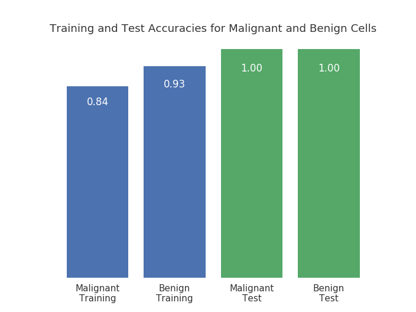

```python
#accuracy_plot()
```